# PRACA DOMOWA 6

## Wstęp

Celem pracy domowej jest przeprowadzenie analizy na zbiorze danych 'Red Wine Quality', przedstawiający informacje na temat białych i czerwonych wariantów portugalskiego wina 'Vinho Verde'. Dane te pochodzą ze strony https://www.kaggle.com/datasets/uciml/red-wine-quality-cortez-et-al-2009.

## Opis Tabelki

### Wczytanie Danych

```python
import pandas as pd
import matplotlib.pyplot as plt
import seaborn as sns
```

```python
df = pd.read_csv('winequality-red.csv')
df.head()
```

|  | fixed acidity | volatile acidity | citric acid | residual sugar | chlorides | free sulfur dioxide | total sulfur dioxide | density | pH | sulphates | alcohol | quality |
| --- | --- | --- | --- | --- | --- | --- | --- | --- | --- | --- | --- | --- |
| 0 | 7.4 | 0.70 | 0.00 | 1.9 | 0.076 | 11.0 | 34.0 | 0.9978 | 3.51 | 0.56 | 9.4 | 5 |
| 1 | 7.8 | 0.88 | 0.00 | 2.6 | 0.098 | 25.0 | 67.0 | 0.9968 | 3.20 | 0.68 | 9.8 | 5 |
| 2 | 7.8 | 0.76 | 0.04 | 2.3 | 0.092 | 15.0 | 54.0 | 0.9970 | 3.26 | 0.65 | 9.8 | 5 |
| 3 | 11.2 | 0.28 | 0.56 | 1.9 | 0.075 | 17.0 | 60.0 | 0.9980 | 3.16 | 0.58 | 9.8 | 6 |
| 4 | 7.4 | 0.70 | 0.00 | 1.9 | 0.076 | 11.0 | 34.0 | 0.9978 | 3.51 | 0.56 | 9.4 | 5 |

```python
df.shape
```

```
(1599, 12)
```

### Opis Kolumn

```python
df.columns
```

```
Index(['fixed acidity', 'volatile acidity', 'citric acid', 'residual sugar',
       'chlorides', 'free sulfur dioxide', 'total sulfur dioxide', 'density',
       'pH', 'sulphates', 'alcohol', 'quality'],
      dtype='object')
```

```python
df.info()
```

```
<class 'pandas.core.frame.DataFrame'>
RangeIndex: 1599 entries, 0 to 1598
Data columns (total 12 columns):
 #   Column                Non-Null Count  Dtype
---  ------                --------------  -----
 0   fixed acidity         1599 non-null   float64
 1   volatile acidity      1599 non-null   float64
 2   citric acid           1599 non-null   float64
 3   residual sugar        1599 non-null   float64
 4   chlorides             1599 non-null   float64
 5   free sulfur dioxide   1599 non-null   float64
 6   total sulfur dioxide  1599 non-null   float64
 7   density               1599 non-null   float64
 8   pH                    1599 non-null   float64
 9   sulphates             1599 non-null   float64
 10  alcohol               1599 non-null   float64
 11  quality               1599 non-null   int64
dtypes: float64(11), int64(1)
memory usage: 150.0 KB
```

- fixed acidity - ilość kwasów związanych z winem
- volatile acidity - kwasowość lotna - ilość kwasu octowego
- citric acid - ilość kwasu cytrynowego
- residual sugar - ilość cukru resztkowego
- chlorides - ilość chlorków (soli)
- free sulfur dioxide - ilość wolnego dwutlenku siarki
- total sulfur dioxide - ilość całkowitego dwutlenku siarki
- density - gęstość
- pH - pH
- sulphates - ilość siarczanów
- alcohol - % alkoholu
- quality - jakość

### Podstawowe Statystyki

```python
df.describe()
```

|  | fixed acidity | volatile acidity | citric acid | residual sugar | chlorides | free sulfur dioxide | total sulfur dioxide | density | pH | sulphates | alcohol | quality |
| --- | --- | --- | --- | --- | --- | --- | --- | --- | --- | --- | --- | --- |
| count | 1599.000000 | 1599.000000 | 1599.000000 | 1599.000000 | 1599.000000 | 1599.000000 | 1599.000000 | 1599.000000 | 1599.000000 | 1599.000000 | 1599.000000 | 1599.000000 |
| mean | 8.319637 | 0.527821 | 0.270976 | 2.538806 | 0.087467 | 15.874922 | 46.467792 | 0.996747 | 3.311113 | 0.658149 | 10.422983 | 5.636023 |
| std | 1.741096 | 0.179060 | 0.194801 | 1.409928 | 0.047065 | 10.460157 | 32.895324 | 0.001887 | 0.154386 | 0.169507 | 1.065668 | 0.807569 |
| min | 4.600000 | 0.120000 | 0.000000 | 0.900000 | 0.012000 | 1.000000 | 6.000000 | 0.990070 | 2.740000 | 0.330000 | 8.400000 | 3.000000 |
| 25% | 7.100000 | 0.390000 | 0.090000 | 1.900000 | 0.070000 | 7.000000 | 22.000000 | 0.995600 | 3.210000 | 0.550000 | 9.500000 | 5.000000 |
| 50% | 7.900000 | 0.520000 | 0.260000 | 2.200000 | 0.079000 | 14.000000 | 38.000000 | 0.996750 | 3.310000 | 0.620000 | 10.200000 | 6.000000 |
| 75% | 9.200000 | 0.640000 | 0.420000 | 2.600000 | 0.090000 | 21.000000 | 62.000000 | 0.997835 | 3.400000 | 0.730000 | 11.100000 | 6.000000 |
| max | 15.900000 | 1.580000 | 1.000000 | 15.500000 | 0.611000 | 72.000000 | 289.000000 | 1.003690 | 4.010000 | 2.000000 | 14.900000 | 8.000000 |

## Wykresy

### Rozkłady Zmiennych

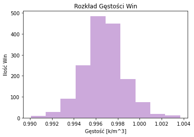

```python
plt.hist(df['density'], color = '#cca9db')
plt.xlabel('Gęstość [k/m^3]')
plt.ylabel('Ilość Win')
plt.title('Rozkład Gęstości Win')
plt.show()
```

Rozkład gęstości win wygląda na symetryczny. Wina mają najczęściej gęstość z przedziału 0.995-0.998.

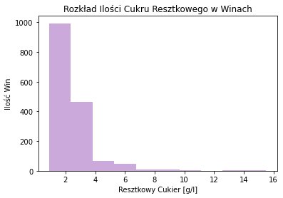

```python
plt.hist(df['residual sugar'], color = '#cca9db')
plt.xlabel('Resztkowy Cukier [g/l]')
plt.ylabel('Ilość Win')
plt.title('Rozkład Ilości Cukru Resztkowego w Winach')
plt.show()
```

Rozkład ilości cukru resztkowego wygląda na prawoskośny. Wina najczęściej mają ok. 0-4 gramów resztkowego cukru na litr wina.

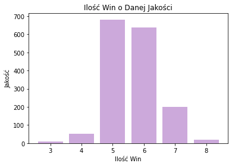

```python
df1 = df.groupby("quality").quality.count().reset_index(name = 'count')
plt.bar(df1['quality'], df1['count'], color = '#cca9db')
plt.ylabel('Jakość')
plt.xlabel('Ilość Win')
plt.title('Ilość Win o Danej Jakości')
plt.show()
```

Mimo, że teoretycznie jakość wina jest w skali 1-10, to nie ma żadnych, które miałby jakość mniejszą niż 3 lub większą niż 8. Najwięcej jest win o jakości 5, 6 i 7. Pozostałe wartości pojawiają się o wiele rzadziej.

### Zależności w Zbiorze Danych

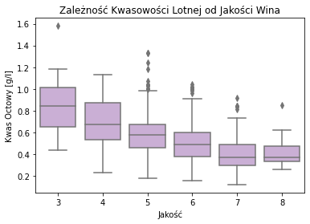

```python
sns.boxplot(data = df, x = 'quality', y = 'volatile acidity', color = '#cca9db')
plt.xlabel('Jakość')
plt.ylabel('Kwas Octowy [g/l]')
plt.title('Zależność Kwasowości Lotnej od Jakości Wina')
plt.show()
```

Możemy zauważyć, że wina o wyższej jakości mają mniejszą kwasowość lotną. Jednakże warto zwrócić uwagę, że jak wiadomo z poprzediego wygresu win o jakości 3, 4 i 8 jest zdecydowanie mniej niż tych o jakości 5, 6 i 7, przez co dane mogą nie być aż tak dokładne.

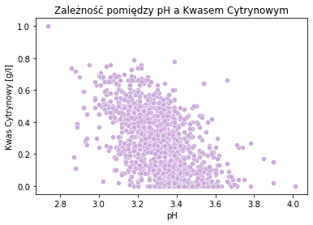

```python
sns.scatterplot(data = df, x = 'pH', y = 'citric acid', color = '#cca9db')
plt.xlabel('pH')
plt.ylabel('Kwas Cytrynowy [g/l]')
plt.title('Zależność pomiędzy pH a Kwasem Cytrynowym')
plt.show()
```

Z wykresu widać, że im więcej w winie jest kwasu cytrynowego, tym ma niższe pH.

## Podsumowanie

- Gęstość wina jest bliska gęstości wody.
- Ilość cukrów resztkowych zazwyczaj jest mniejsza niż 4 gramy na litr wina.
- Jakość win jest najczęściej oceniana jako 5 lub 6 na 10.
- Większe ilości kwasu octowego mogą powodować nieprzyjemny octowy smak, który może być przyczyną tego, że wina o niższej jakości zawierają go przeciętnie więcej.
- Niższe pH wina może wynikać z wyższej zawartości kwasu cytrynowego, które ma kwasowe pH.